# Peer Assessment I

First, let us load the data and necessary packages:

```r
load("ames_train.Rdata")
library(MASS)
library(BAS)
library(dplyr)
```

```r
library(ggplot2)
library(devtools)
library(statsr)
```

# 1

Make a labeled histogram (with 30 bins) of the ages of the houses in the data set, and describe the distribution.

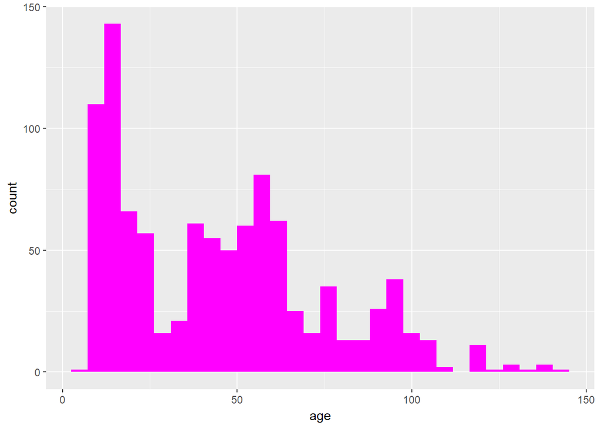

```r
ames_train <- ames_train %>%
        mutate(age = 2017 - Year.Built)
ggplot(ames_train, aes(x=age), labs(title = "Distribution of House Age", y = "Number of Houses", x = "Age of the House in 2017")) + geom_histogram(bins=30, fill = 'Magenta')
```

```r
summary(ames_train$age)
```

```
##    Min. 1st Qu.  Median    Mean 3rd Qu.    Max.
##     7.0    16.0    42.0    44.8    62.0   145.0
```

# 2

The mantra in real estate is “Location, Location, Location!” Make a graphical display that relates a home price to its neighborhood in Ames, Iowa. Which summary statistics are most appropriate to use for determining the most expensive, least expensive, and most heterogeneous (having the most variation in housing price) neighborhoods? Report which neighborhoods these are based on the summary statistics of your choice. Report the value of your chosen summary statistics for these neighborhoods.

```r
ames_train %>%
        select(price, Neighborhood) %>%
        group_by(Neighborhood) %>%
                summarise(median = median(price), max = max(price), min = min(price), sd = sd(price)) %>% arrange(desc(median))
```

```
## # A tibble: 27 x 5
##    Neighborhood   median    max    min        sd
##          <fctr>    <dbl>  <dbl>  <dbl>     <dbl>
##  1      StoneBr 340691.5 591587 180000 123459.10
##  2      NridgHt 336860.0 615000 173000 105088.90
##  3      NoRidge 290000.0 405000 235000  35888.97
##  4      GrnHill 280000.0 330000 230000  70710.68
##  5       Timber 232500.0 425000 175000  84029.57
##  6      Somerst 221650.0 468000 139000  65199.49
##  7       Greens 212625.0 214000 155000  29063.42
##  8      Veenker 205750.0 385000 150000  72545.41
##  9      Crawfor 205000.0 392500  96500  71267.56
## 10      CollgCr 195800.0 475000 110000  52786.08
## # ... with 17 more rows
```

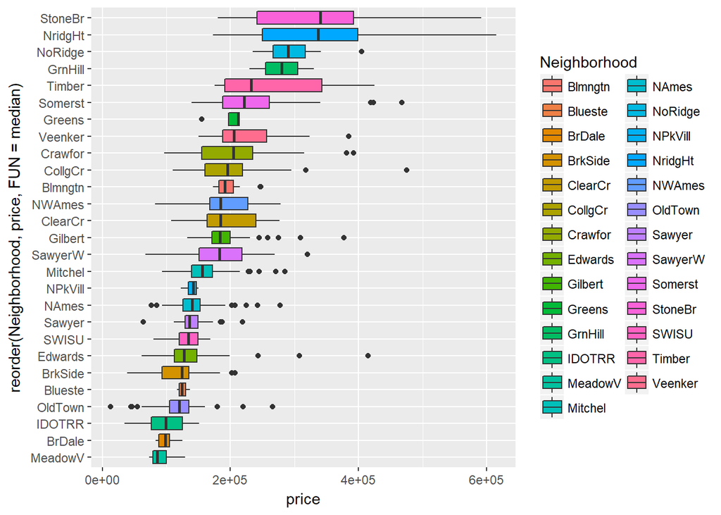

```r
ggplot(ames_train, aes(y = price, x = reorder(Neighborhood, price, FUN = median), fill = Neighborhood), main = "Price among Neighborhoods", xlim= "Neighborhood", ylim="Price" )+geom_boxplot() + coord_flip()
```

# 3

Which variable has the largest number of missing values? Explain why it makes sense that there are so many missing values for this variable.

```r
apply(ames_train, 2, function(x) sum(is.na(x))) %>% sort %>% tail
```

```
## Lot.Frontage Fireplace.Qu        Fence        Alley Misc.Feature
##          167          491          798          933          971
##      Pool.QC
##          997
```

This number is high because “NA” is coded as “No Pool” in the data and most homes do not have a pool.

# 4

We want to predict the natural log of the home prices. Candidate explanatory variables are lot size in square feet (Lot.Area), slope of property (Land.Slope), original construction date (Year.Built), remodel date (Year.Remod.Add), and the number of bedrooms above grade (Bedroom.AbvGr). Pick a model selection or model averaging method covered in the Specialization, and describe how this method works. Then, use this method to find the best multiple regression model for predicting the natural log of the home prices.

```r
model_lm = lm(log(price)~Lot.Area+Land.Slope
         +Year.Built+Year.Remod.Add
        +Bedroom.AbvGr, data = ames_train)

summary(model_lm)
```

```
##
## Call:
## lm(formula = log(price) ~ Lot.Area + Land.Slope + Year.Built +
##     Year.Remod.Add + Bedroom.AbvGr, data = ames_train)
##
## Residuals:
##     Min      1Q  Median      3Q     Max
## -2.0878 -0.1651 -0.0211  0.1657  0.9945
##
## Coefficients:
##                  Estimate Std. Error t value Pr(>|t|)
## (Intercept)    -1.371e+01  8.574e-01 -15.996  < 2e-16 ***
## Lot.Area        1.028e-05  1.106e-06   9.296  < 2e-16 ***
## Land.SlopeMod   1.384e-01  4.991e-02   2.773  0.00565 **
## Land.SlopeSev  -4.567e-01  1.514e-01  -3.016  0.00263 **
## Year.Built      6.049e-03  3.788e-04  15.968  < 2e-16 ***
## Year.Remod.Add  6.778e-03  5.468e-04  12.395  < 2e-16 ***
## Bedroom.AbvGr   8.686e-02  1.077e-02   8.063 2.12e-15 ***
## ---
## Signif. codes:  0 '***' 0.001 '**' 0.01 '*' 0.05 '.' 0.1 ' ' 1
##
## Residual standard error: 0.279 on 993 degrees of freedom
## Multiple R-squared:  0.5625, Adjusted R-squared:  0.5598
## F-statistic: 212.8 on 6 and 993 DF,  p-value: < 2.2e-16
```

```r
model_bic = bas.lm(log(price)~Lot.Area+Land.Slope
         +Year.Built+Year.Remod.Add
        +Bedroom.AbvGr, data = ames_train,
        prior = "BIC",
        modelprior = uniform(),
        method = "MCMC" )
summary(model_bic)
```

```
##                P(B != 0 | Y)    model 1       model 2      model 3
## Intercept          1.0000000     1.0000     1.0000000     1.000000
## Lot.Area           0.9976563     1.0000     1.0000000     1.000000
## Land.SlopeMod      0.6679688     1.0000     0.0000000     1.000000
## Land.SlopeSev      0.8015625     1.0000     1.0000000     0.000000
## Year.Built         1.0000000     1.0000     1.0000000     1.000000
## Year.Remod.Add     0.9984375     1.0000     1.0000000     1.000000
## Bedroom.AbvGr      0.9914063     1.0000     1.0000000     1.000000
## BF                        NA     1.0000     0.6674353     0.330911
## PostProbs                 NA     0.5094     0.2914000     0.158600
## R2                        NA     0.5625     0.5591000     0.558500
## dim                       NA     7.0000     6.0000000     6.000000
## logmarg                   NA -2198.1673 -2198.5716571 -2199.273250
##                      model 4       model 5
## Intercept          1.0000000  1.000000e+00
## Lot.Area           1.0000000  1.000000e+00
## Land.SlopeMod      0.0000000  0.000000e+00
## Land.SlopeSev      0.0000000  0.000000e+00
## Year.Built         1.0000000  1.000000e+00
## Year.Remod.Add     1.0000000  1.000000e+00
## Bedroom.AbvGr      1.0000000  0.000000e+00
## BF                 0.1061955  6.841724e-14
## PostProbs          0.0320000  5.500000e-03
## R2                 0.5544000  5.254000e-01
## dim                5.0000000  4.000000e+00
## logmarg        -2200.4098178 -2.228480e+03
```

We choose the appropriate model to implement using Bayesian model averaging (BMA), in which multiple models are averaged to obtain posteriors of coefficients and predictions from ata. BIC is selected as a prior distribution because it provides highest Posterior Probabilities values among all others methods. Running BMA (BIC and MCMC), we can see that the model suggests to keep all variables as the best fitted predictors of the home price. If we had a look at the linear model and would chose to eliminate a few variables to reach the final model, we would not touch any of them, either.

# 5

Which home has the largest squared residual in the previous analysis (Question 4)? Looking at all the variables in the data set, can you explain why this home stands out from the rest (what factors contribute to the high squared residual and why are those factors relevant)?

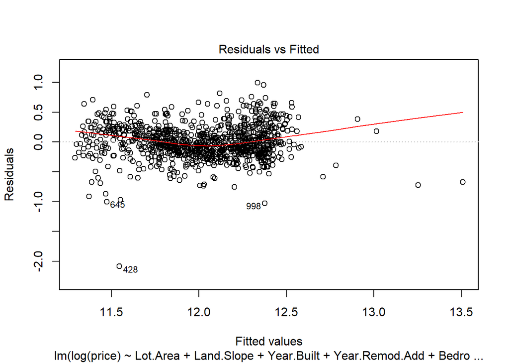

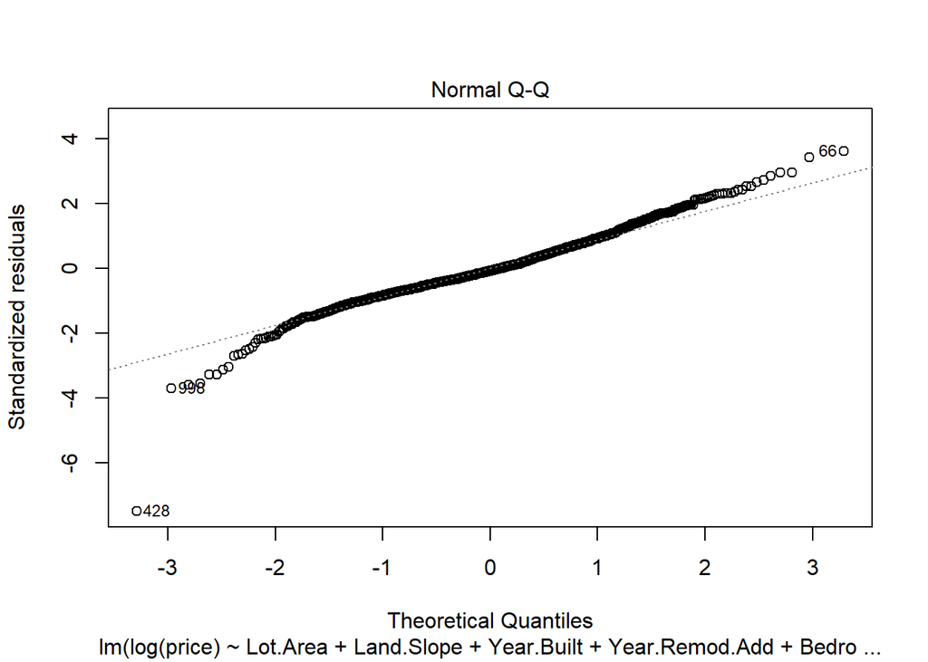

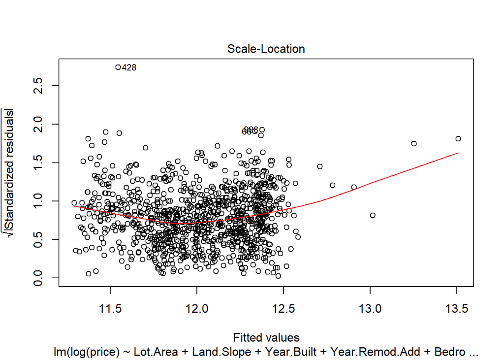

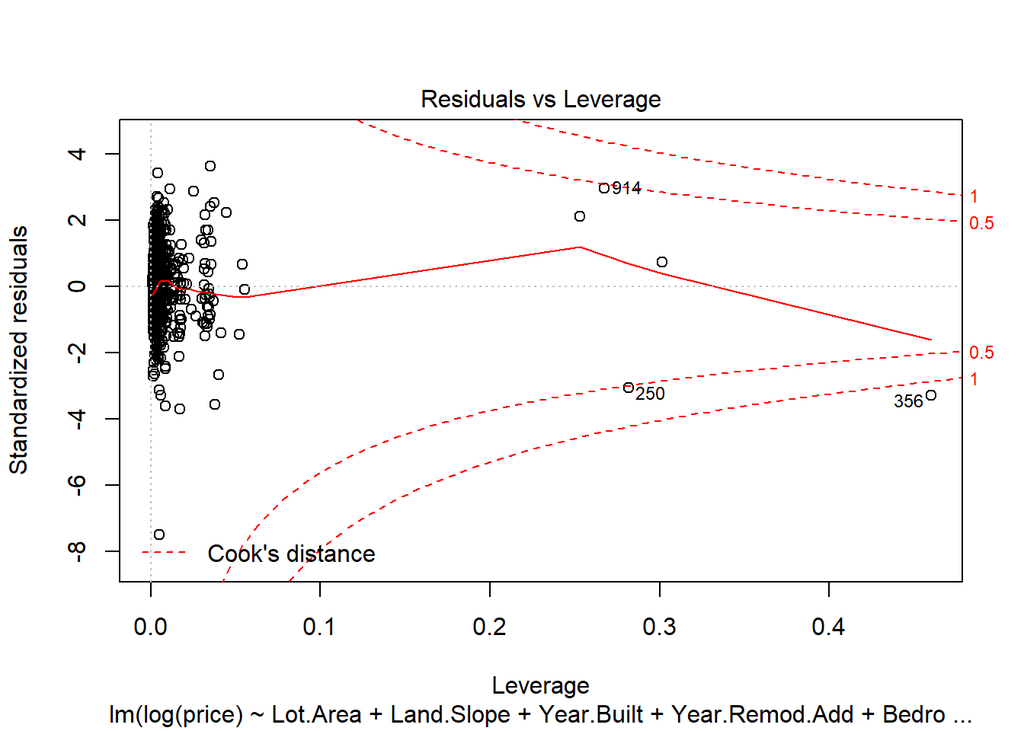

```r
plot(model_lm)
```

```r
outlierHouse <- ames_train[which(model_lm$residuals^2 == max((model_lm$residuals)^2)),]
outlierHouse
```

```
## # A tibble: 1 x 82
##         PID  area price MS.SubClass MS.Zoning Lot.Frontage Lot.Area Street
##       <int> <int> <int>       <int>    <fctr>        <int>    <int> <fctr>
## 1 902207130   832 12789          30        RM           68     9656   Pave
## # ... with 74 more variables: Alley <fctr>, Lot.Shape <fctr>,
## #   Land.Contour <fctr>, Utilities <fctr>, Lot.Config <fctr>,
## #   Land.Slope <fctr>, Neighborhood <fctr>, Condition.1 <fctr>,
## #   Condition.2 <fctr>, Bldg.Type <fctr>, House.Style <fctr>,
## #   Overall.Qual <int>, Overall.Cond <int>, Year.Built <int>,
## #   Year.Remod.Add <int>, Roof.Style <fctr>, Roof.Matl <fctr>,
## #   Exterior.1st <fctr>, Exterior.2nd <fctr>, Mas.Vnr.Type <fctr>,
## #   Mas.Vnr.Area <int>, Exter.Qual <fctr>, Exter.Cond <fctr>,
## #   Foundation <fctr>, Bsmt.Qual <fctr>, Bsmt.Cond <fctr>,
## #   Bsmt.Exposure <fctr>, BsmtFin.Type.1 <fctr>, BsmtFin.SF.1 <int>,
## #   BsmtFin.Type.2 <fctr>, BsmtFin.SF.2 <int>, Bsmt.Unf.SF <int>,
## #   Total.Bsmt.SF <int>, Heating <fctr>, Heating.QC <fctr>,
## #   Central.Air <fctr>, Electrical <fctr>, X1st.Flr.SF <int>,
## #   X2nd.Flr.SF <int>, Low.Qual.Fin.SF <int>, Bsmt.Full.Bath <int>,
## #   Bsmt.Half.Bath <int>, Full.Bath <int>, Half.Bath <int>,
## #   Bedroom.AbvGr <int>, Kitchen.AbvGr <int>, Kitchen.Qual <fctr>,
## #   TotRms.AbvGrd <int>, Functional <fctr>, Fireplaces <int>,
## #   Fireplace.Qu <fctr>, Garage.Type <fctr>, Garage.Yr.Blt <int>,
## #   Garage.Finish <fctr>, Garage.Cars <int>, Garage.Area <int>,
## #   Garage.Qual <fctr>, Garage.Cond <fctr>, Paved.Drive <fctr>,
## #   Wood.Deck.SF <int>, Open.Porch.SF <int>, Enclosed.Porch <int>,
## #   X3Ssn.Porch <int>, Screen.Porch <int>, Pool.Area <int>,
## #   Pool.QC <fctr>, Fence <fctr>, Misc.Feature <fctr>, Misc.Val <int>,
## #   Mo.Sold <int>, Yr.Sold <int>, Sale.Type <fctr>, Sale.Condition <fctr>,
## #   age <dbl>
```

```r
predictedPrice <- exp(model_lm$fitted.values[which(model_lm$residuals^2 == max((model_lm$residuals)^2))])
predictedPrice
```

```
##      428
## 103176.2
```

# 6

Use the same model selection method you chose in Question 4 to again find the best multiple regression model to predict the natural log of home prices, but this time **replacing Lot.Area with log(Lot.Area)**. Do you arrive at a model including the same set of predictors?

```r
model_bic = bas.lm(log(price) ~ log(Lot.Area)+Land.Slope
         +Year.Built+Year.Remod.Add
        +Bedroom.AbvGr, data = ames_train,
        prior = "BIC",
        modelprior = uniform(),
        method = "MCMC" )
summary(model_bic)
```

```
##                P(B != 0 | Y)    model 1       model 2       model 3
## Intercept          1.0000000     1.0000     1.0000000  1.000000e+00
## log(Lot.Area)      0.9867187     1.0000     1.0000000  1.000000e+00
## Land.SlopeMod      0.3695312     0.0000     1.0000000  0.000000e+00
## Land.SlopeSev      0.0406250     0.0000     0.0000000  1.000000e+00
## Year.Built         1.0000000     1.0000     1.0000000  1.000000e+00
## Year.Remod.Add     0.9921875     1.0000     1.0000000  1.000000e+00
## Bedroom.AbvGr      0.9906250     1.0000     1.0000000  1.000000e+00
## BF                        NA     1.0000     0.6494644  3.866294e-02
## PostProbs                 NA     0.6016     0.3492000  2.030000e-02
## R2                        NA     0.6031     0.6055000  6.032000e-01
## dim                       NA     5.0000     6.0000000  6.000000e+00
## logmarg                   NA -2142.5652 -2142.9968106 -2.145818e+03
##                      model 4       model 5
## Intercept       1.000000e+00  1.000000e+00
## log(Lot.Area)   1.000000e+00  0.000000e+00
## Land.SlopeMod   1.000000e+00  1.000000e+00
## Land.SlopeSev   1.000000e+00  0.000000e+00
## Year.Built      1.000000e+00  1.000000e+00
## Year.Remod.Add  1.000000e+00  0.000000e+00
## Bedroom.AbvGr   1.000000e+00  0.000000e+00
## BF              2.374021e-02  8.298076e-87
## PostProbs       1.560000e-02  4.700000e-03
## R2              6.056000e-01  4.018000e-01
## dim             7.000000e+00  3.000000e+00
## logmarg        -2.146306e+03 -2.340774e+03
```

Modifying the variable Lot.Area by natural log, we get slightly different model. The new model now suggest that we remove both the Land.Slope variables!!

# 7

Do you think it is better to log transform Lot.Area, in terms of assumptions for linear regression? Make graphs of the predicted values of log home price versus the true values of log home price for the regression models selected for Lot.Area and log(Lot.Area). Referencing these two plots, provide a written support that includes a quantitative justification for your answer in the first part of question 7.

```r
model_lm_1 = lm(log(price)~Lot.Area+Land.Slope
         +Year.Built+Year.Remod.Add
        +Bedroom.AbvGr, data = ames_train)

model_lm_2 = lm(log(price)~log(Lot.Area)+Land.Slope
         +Year.Built+Year.Remod.Add
        +Bedroom.AbvGr, data = ames_train)

summary(model_lm_1)
```

```
##
## Call:
## lm(formula = log(price) ~ Lot.Area + Land.Slope + Year.Built +
##     Year.Remod.Add + Bedroom.AbvGr, data = ames_train)
##
## Residuals:
##     Min      1Q  Median      3Q     Max
## -2.0878 -0.1651 -0.0211  0.1657  0.9945
##
## Coefficients:
##                  Estimate Std. Error t value Pr(>|t|)
## (Intercept)    -1.371e+01  8.574e-01 -15.996  < 2e-16 ***
## Lot.Area        1.028e-05  1.106e-06   9.296  < 2e-16 ***
## Land.SlopeMod   1.384e-01  4.991e-02   2.773  0.00565 **
## Land.SlopeSev  -4.567e-01  1.514e-01  -3.016  0.00263 **
## Year.Built      6.049e-03  3.788e-04  15.968  < 2e-16 ***
## Year.Remod.Add  6.778e-03  5.468e-04  12.395  < 2e-16 ***
## Bedroom.AbvGr   8.686e-02  1.077e-02   8.063 2.12e-15 ***
## ---
## Signif. codes:  0 '***' 0.001 '**' 0.01 '*' 0.05 '.' 0.1 ' ' 1
##
## Residual standard error: 0.279 on 993 degrees of freedom
## Multiple R-squared:  0.5625, Adjusted R-squared:  0.5598
## F-statistic: 212.8 on 6 and 993 DF,  p-value: < 2.2e-16
```

```r
summary(model_lm_2)
```

```
##
## Call:
## lm(formula = log(price) ~ log(Lot.Area) + Land.Slope + Year.Built +
##     Year.Remod.Add + Bedroom.AbvGr, data = ames_train)
##
## Residuals:
##      Min       1Q   Median       3Q      Max
## -2.14050 -0.15650 -0.01561  0.15350  0.90854
##
## Coefficients:
##                  Estimate Std. Error t value Pr(>|t|)
## (Intercept)    -1.553e+01  8.197e-01 -18.947  < 2e-16 ***
## log(Lot.Area)   2.442e-01  1.708e-02  14.297  < 2e-16 ***
## Land.SlopeMod   1.151e-01  4.734e-02   2.431   0.0152 *
## Land.SlopeSev  -6.554e-02  1.222e-01  -0.536   0.5917
## Year.Built      5.981e-03  3.597e-04  16.628  < 2e-16 ***
## Year.Remod.Add  6.734e-03  5.190e-04  12.975  < 2e-16 ***
## Bedroom.AbvGr   5.909e-02  1.055e-02   5.599  2.8e-08 ***
## ---
## Signif. codes:  0 '***' 0.001 '**' 0.01 '*' 0.05 '.' 0.1 ' ' 1
##
## Residual standard error: 0.2649 on 993 degrees of freedom
## Multiple R-squared:  0.6056, Adjusted R-squared:  0.6032
## F-statistic: 254.1 on 6 and 993 DF,  p-value: < 2.2e-16
```

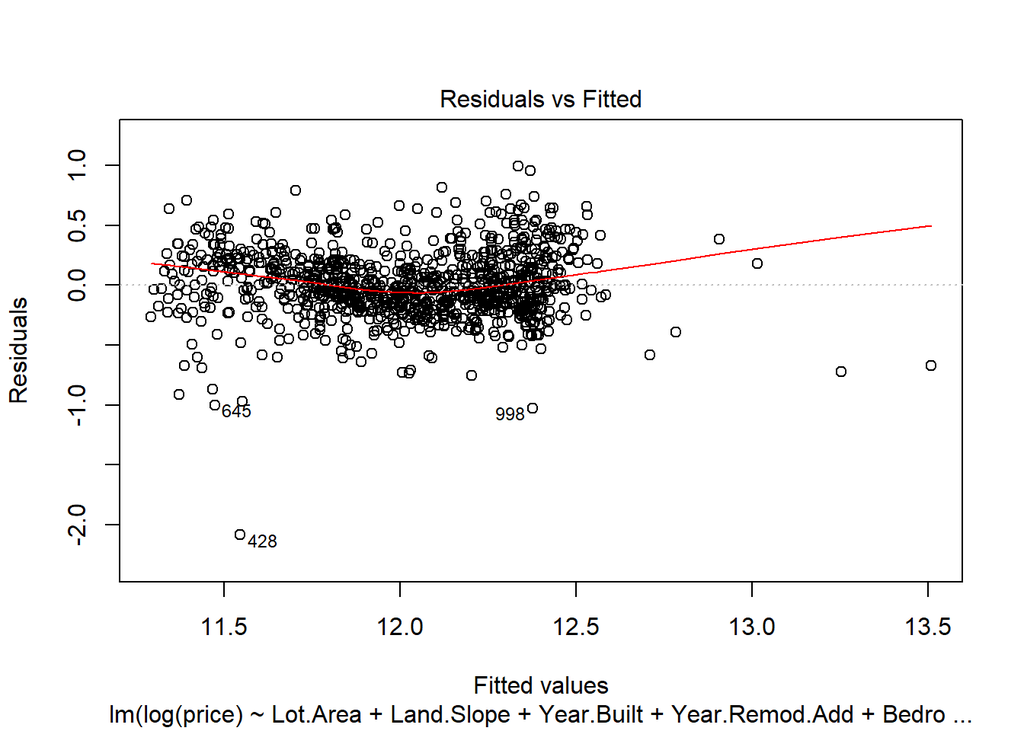

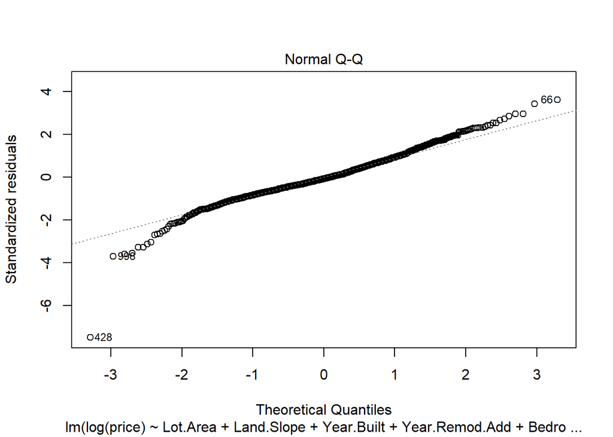

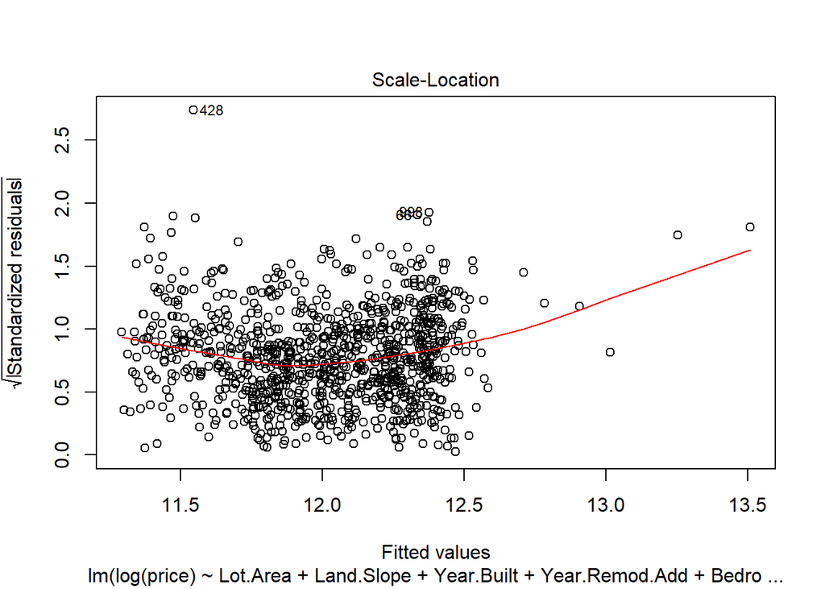

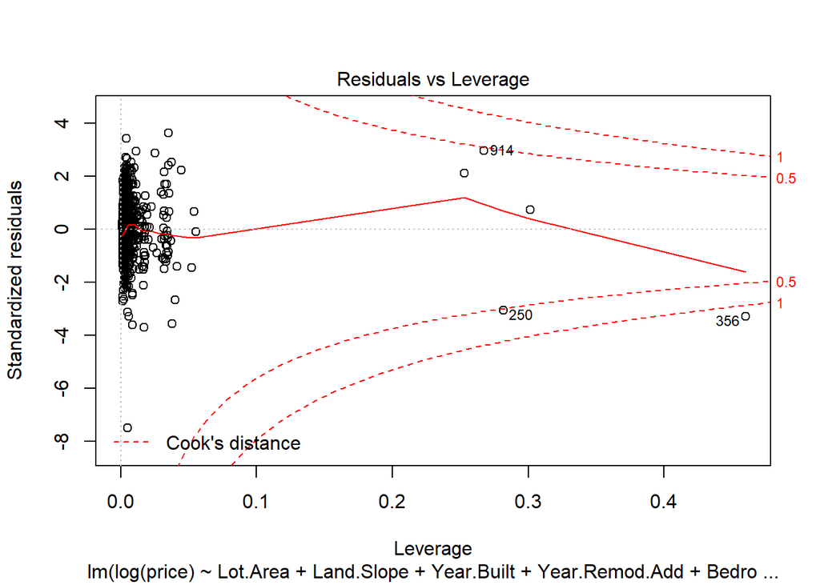

```r
plot(model_lm_1)
```

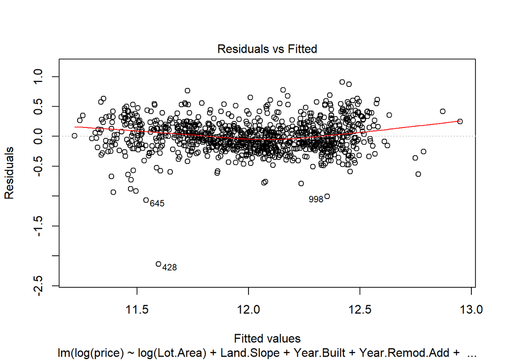

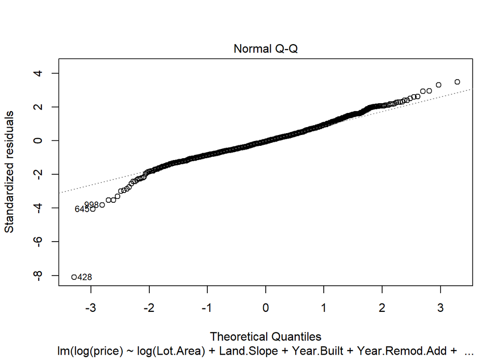

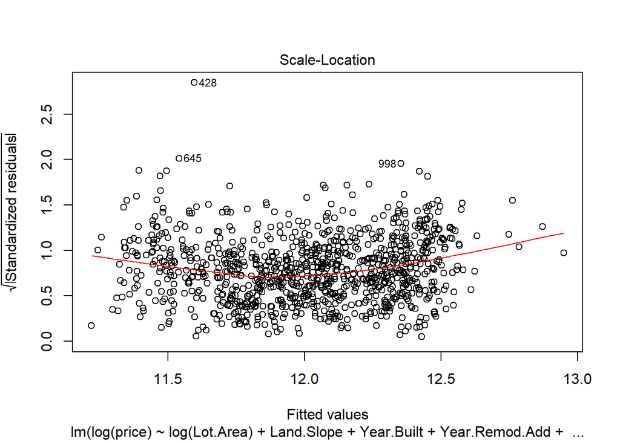

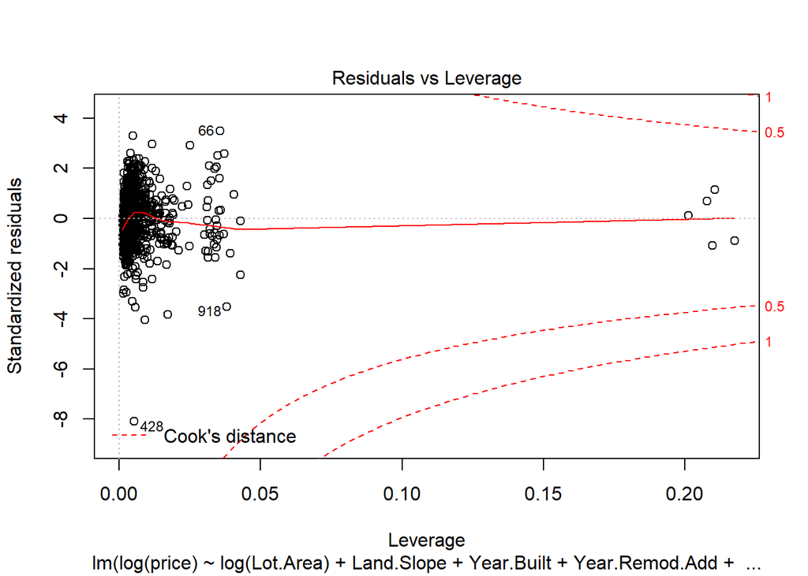

```r
plot(model_lm_2)
```

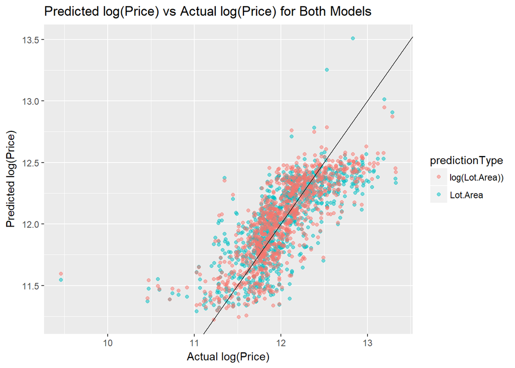

```r
log_ActualPrice <- log(ames_train$price)
predict_model_1 <- predict.lm(model_lm_1, ames_train)
predict_model_2 <- predict.lm(model_lm_2, ames_train)

plotDataFrame = data.frame(log_ActualPrice = log_ActualPrice, PredictedPrice = c(predict_model_1, predict_model_2), predictionType=c(rep(c("Lot.Area"),1000),rep(c("log(Lot.Area))"),1000)), difference = c((log_ActualPrice - predict_model_1), (log_ActualPrice - predict_model_2)))

ggplot(data=plotDataFrame, aes(x = log_ActualPrice, y = PredictedPrice, color = predictionType)) +
    geom_point(, alpha = 0.5) +
    geom_abline(slope=1, intercept=0) +
    labs(title = "Predicted log(Price) vs Actual log(Price) for Both Models", y = "Predicted log(Price)", x = "Actual log(Price)")
```

- Both plots of the predicted prices versus actual prices for each model are included in the same plot. A y=x corresponding to perfect prediction for all values of price is also added to provide a refrence. The plot shows that the results from both models are quite similar.
- The Adjusted R squared values however do show that log transformation does improvde modelling as the value of Rsquared increases from 0.56 tp .060.
- However are the differences observed between the predicted and actual prices for the two models statistically different. Lets find out! To confirm what we observed in the graph a hypothesis test with the null hypothesis that both results are actually equivalent is conducted.

```
## Response variable: numerical
## Explanatory variable: categorical (2 levels)
## n_Lot.Area = 1000, y_bar_Lot.Area = 0, s_Lot.Area = 0.2782
## n_log(Lot.Area)) = 1000, y_bar_log(Lot.Area)) = 0, s_log(Lot.Area)) = 0.2641
## H0: mu_Lot.Area =  mu_log(Lot.Area))
## HA: mu_Lot.Area != mu_log(Lot.Area))
## t = 0, df = 999
## p_value = 1
```

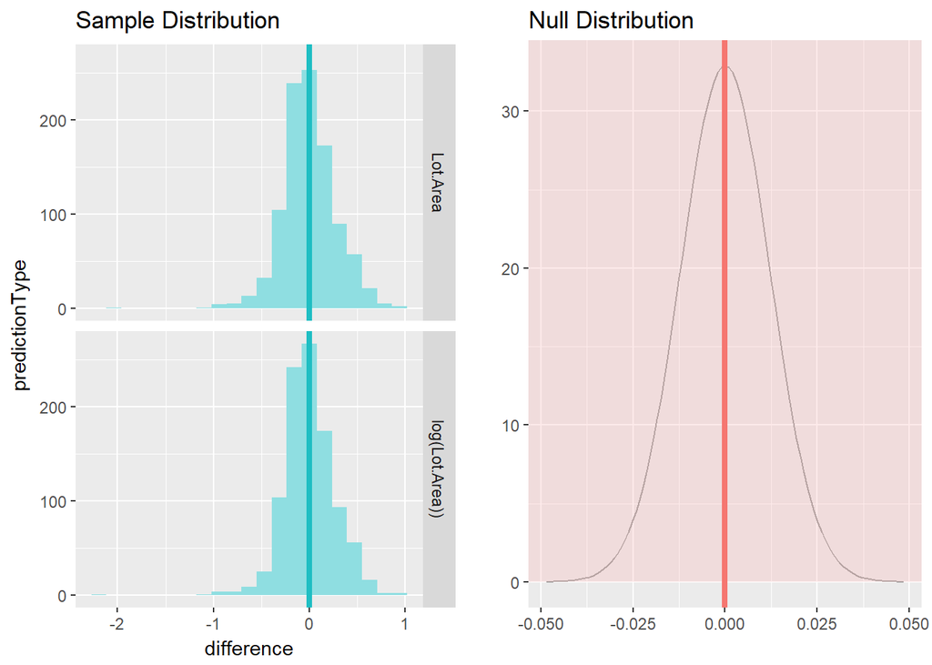

```r
inference(y = difference, x = predictionType, data = plotDataFrame, statistic = "mean", type = "ht", null = 0,
          alternative = "twosided", conf_level = 0.95, method = "theoretical", order = c("log(Lot.Area)","Lot.Area"))
```

- As shown above the p-value for this test is one, i.e. there is not sufficient evidence to reject the null hypothesis and a statistically significant difference in results for both models is not present